# Executive Summary

1. Across all available metrics of success, Spotify-created playlists are much more successful than nearly all user-created playlists.
2. We consider nine metrics of playlist success, including measures of total streams and total users over the past day, week, month and two months. Amongst both the user-created and Spotify-created playlists, these measures of success are very highly correlated with one another, thus suggesting any choice of these success metrics would likely be sufficient.
3. Across both Spotify-created and user-created playlists, the number of tracks is the most important predictor of short-term and long-term playlist success, with longer playlists tending to be more successful.
4. For Spotify-created playlists, having greater musical diversity (as measured by tracks per album and tracks per artist) is associated with increased success. This effect is present for the user-created playlists, but is less pronounced.
5. Greater musical diversity is more important for a playlist's long-term staying power than for short-term success, with one of the musical diversity metrics being the second most important predictor (behind total tracks) for the long-term success metric.
6. For Spotify-created playlists, the primary genres of 'dance & house' and 'pop' are associated with both short-term and long-term success.
7. The most success-inducing primary genres for Spotify-created and user-created vary considerably. For user-created playlists, "Children's", "Latin" and "Traditional" increase both short- and long-term success.

```python
%%capture
# Game Plan:
# 1. Show that the choice of outcome variable does not matter very much because of the extremely high correlation between potential outcomes.
#     - Create a nice looking correlation plot for the outcomes
#     -  Probably try to create the sns.pairplot() although that function was very very slow
# 2.  Point out that the Spotify playlists are MUCH more successful than the typical user playlist
#     - Can show that by plotting bar charts next to each other, group by whether owner == "spotify"
# 3.  Have to make a decision on what outcome variable to choose (or most likely a combination of outcome variables!)
# 4.  Look at univariate cuts of the outcome variable(s) with the predictors, just to try to give a sense of the relationship between the variables prior to modeling
# 5.  Build a baseline model that we can use for prediction and then we can compare this to a more advanced model -- will allow for simpler interpretations
# 6.  Build an ML model that we can then go compare efficacy with the baseline model.

# Note:
# 1.  We will likely want to run separate analyses broken out by owner == 'spotify' vs owner != 'spotify'
#     a.  See if the importance of the other predictors is comparable for the two groups
# 2.  If a user streams 2 or more songs consecutively, does that count as 2 streams or only 1 since the stream were consecutive?


# Possible Options (no particular order)
# 1.  Look into multivariate methods to accommodate the various potential outcome variables (or could just pick one/create a PCA)
# 2.  Should probably think through how to use the 'skippers' data.  Could this be at all helpful in dealing with potential biases in how Spotify may promote playlists?
```

```python
import numpy as np
import pandas as pd
import seaborn as sns
import sklearn
import matplotlib.pyplot as plt
import lightgbm as lgb
from sklearn.decomposition import FactorAnalysis, PCA
from sklearn.preprocessing import StandardScaler, OneHotEncoder
from sklearn.linear_model import MultiTaskLassoCV
from sklearn.model_selection import KFold
import shap
import statsmodels.api as sm
import statsmodels.formula.api as smf
from patsy import dmatrices
pd.set_option('display.max_columns', None)
import warnings
warnings.filterwarnings('ignore')
%matplotlib inline
```

```python
outcome_vars_dict = {'streams': 'streams_today_any',
                    'stream30s': 'streams_today_30s',
                    'monthly_stream30s': 'streams_month_30s',
                    'dau': 'users_today_30s',
                    'wau': 'users_week_30s',
                    'mau': 'users_month_30s',
                     'users': 'users_month_any',
                    'mau_previous_month': 'users_previousmonth_30s',
                    'mau_both_months': 'users_bothmonths_30s',
               }

outcome_vars = list(outcome_vars_dict.values())


raw_data = pd.read_table('data/playlist_summary_external.txt')
raw_data = raw_data.rename(columns = outcome_vars_dict)
spotify_data = raw_data.query('owner == "spotify"')
nonspotify_data = raw_data.query('owner != "spotify"')
# outcome_vars = ['streams',
#                 'stream30s',
#                 'dau',
#                 'wau',
#                 'mau',
#                 'mau_previous_month',
#                 'mau_both_months',
#                 'users',
#                 'monthly_stream30s',
#                ]




predictor_vars = ['n_tracks',
                 'n_local_tracks',
                  'n_artists',
                  'n_albums',
                  'genre_1',
                  'genre_2',
                  'genre_3',
                  'mood_1',
                  'mood_2',
                  'mood_3'
                 ]
```

# Outline

1. Explore massive differences in playlist success between the Spotify-created and user-created playlists.
2. Establish the substantial correlation between each of the measures of success across both Spotify-created and user-created playlists will next be discussed. A principal components analysis will be performed.
3. Briefly present the distribution of the predictors of success, including both the numeric (number of tracks, tracks per artist and tracks per album) as well as the categorical (the mood and genre variables).
4. Fit gradient boosting models to predict measures of both short-term and long-term success, stratifying by Spotify-created and user-created playlists. Use SHAP values to assess the inferential implactions of the models.
5. The Appendix contains a number of other subanalyses and assumption checks.

# Introduction

The data under consideration for these analyses consists of 403,366 distinct playlists, with 314,899 distinct playlist owners. Of the 314,899 unique playlist owners, 261,040 (83%) have exactly one playlist in the data. Of the owners with more than one playlist, Spotify itself has the most, with 399. The data is composed of only playlists from US owners, and thus extrapolating any of these analyses to other countries is likely unwarranted or should be done with great caution. Each playlist is categorized by its top three genres and top three moods. There are 26 genres and 27 moods under consideration.

There are a number of potential measures of playlist success included in this dataset. Specifically, we have (1) the number of streams of any length from the playlist today, (2) the number of streams greater than 30 seconds today, (3) the number of active users today, where an active user is defined as having a stream $>30$ seconds, (4) the number of active users in the past week, (5) the number of active users in the past month, (6) the number of users who had a stream from this playlist for any length of time in the past month, (7) the number of active users in the previous month, (8) the total number of $>30$ second streams in the past month, (9) the number of users who were active this month and the previous month. The data also contains a variable signifying the number of $>30$ second streams by the playlist owner in the past month, but this analysis will focus on broader measures of success, and thus we will not analyze this variable. Finally, the data also includes the number of users who skipped more than 90% of their total streams today who also used this playlist. This variable does not directly measure the proportion of skips for each playlist, but instead measures simply whether users who skip often listen to this playlist. Thus variable will thus also not be included in these analyses.

Some of the potential predictors of stream success include: (1) the number of tracks in the playlist, (2) the number of tracks that were added to the playlist today, (3) The number of unique artists in the playlist, (4) the number of unique albums in the playlist, (5-7) the first, second and third most common genre found in the playlist, (8-10) the first, second and third most common mood found in the playlist. While number of tracks, artists and albums are each measures of playlist size, the most direct measure is number of tracks, so we will thus use it directly in the analyses. We will use number of tracks per artist and number of tracks per album as inverse measures of musical diversity. The dataset also contains unstructured tokens associated with each playlist. Due to the time constraints for these analyses and the unstructured nature of the data, these tokens will not be considered in the analyses.

# Comparing Spotify-Created and User-Created Playlists

There are two Spotify-created playlists that constitute extreme outliers across each of the potential outcome variables. The first is a pop, Dance & House, Indie Rock playlist with 100 tracks and has tokens 'top', 'tracks', 'currently', 'spotify'. The second is a pop, R&B, Dance & House with 51 tracks and has tokens 'top', and 'hits'. These two playlists have more than three times as many streams today as their nearest competitor and more than four times as many $>30$ second streams in the past month as the nearest competitor. For the purposes of plotting, these playlists will be removed.

Even after removing the two most successful Spotify-created playlists, there is still a wide gulf between the Spotify-created and user-created playlists. To illustrate this, consider the boxen plot below, which shows the distribution of each of the potential outcome variables stratified by whether the playlist is creator type. We observe that the Spotify-created playlists are much more successful than the vast majority of user-created playlists. However, there are a few user-created playlists that can rival an average Spotify-created playlist.

```python
raw_data['spotify_created'] = raw_data['owner'] == 'spotify'
comparison_data = (raw_data.
                   drop(index = [163726, 152032]).
                   loc[:, ['spotify_created'] + outcome_vars].
                   melt(id_vars = 'spotify_created',
                       var_name = 'outcome',
                       value_name = 'value')
                  )
```

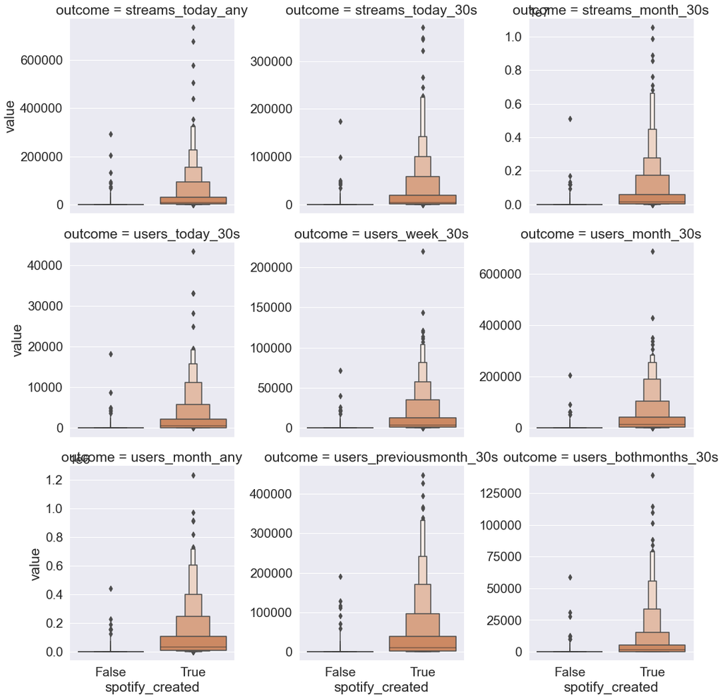

```python
sns.set(font_scale = 1.75)
#plt.figure(font_scale = 1.75)
p = sns.catplot(data = comparison_data,
            kind = 'boxen',
            col = 'outcome',
            col_wrap = 3,
            sharey = False,
            y = 'value',
            x = 'spotify_created')

#p.fig.suptitle('Distribution of Various Measures of Playlist Success Stratified by Creator Type')
```

# Exploration of Potential Outcomes

Because there is such an enormous difference between Spotify-created and user-created playlists, we will continue our data exploration stratifying by whether the playlist is Spotify-created.

To begin understanding the relationship between the potential outcomes of interest, we present a heatmap of the Pearson correlation between each of the outcomes. We create one such heatmap for the user-created playlists and another for the Spotify-created playlists. Amongst the user-created playlists, we see that the minimum correlation between any of the outcomes is 0.78, thus signifying a great deal of correlation between our potential outcomes. While all potential outcomes are highly correlated, the mostly weakly correlated outcomes are the outcomes related to playlists' longer-term success (i.e. the monthly average users in the given month and the previous month) with the more recent measures of success (i.e. the number of total and >30 second streams today and the number of active users today and in the past week). Amongst the Spotify-created playlists, the potential outcomes are even more highly correlated, with the smallest correlation being 0.91. The Spotify-created playlists exhibit a similar general pattern as the user-created in that the weakest correlation between the outcomes is between the more long-term measures of success and the measures of success in the more recent past. However, the degree of correlation is still immense between monthly active users over the past two months and the number of streams that occurred today, thus indicating that Spotify playlists tend to have considerable 'staying power'. Of course, if more successful playlists in the past are algorithmically pushed to users, then this could become a self-fulfilling prophecy rather than a true indication of how 'intrinsically good' the playlist is.

```python
def plot_outcome_corr(data):
    plot_data = data.loc[:, outcome_vars]
    plot_data_corr = plot_data.corr()
    #sns.set(rc = {'figure.figsize': (10, 5)})
    plt.figure(figsize = (10, 5))
    return plot_data, sns.heatmap(plot_data_corr, annot = True, cmap = 'BrBG')
```

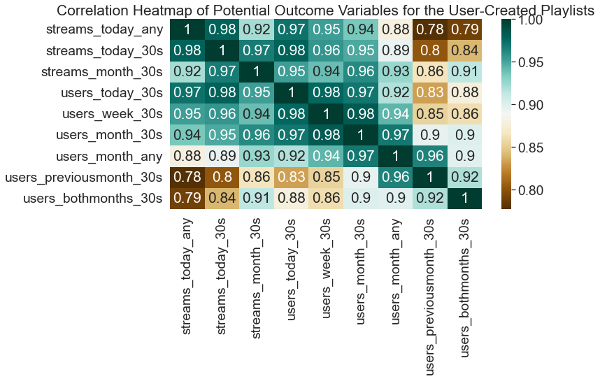

```python
#%%capture
nonspotify_outcome_data, nonspotify_heatmap = plot_outcome_corr(nonspotify_data)
nonspotify_heatmap.set_title('Correlation Heatmap of Potential Outcome Variables for the User-Created Playlists');
```

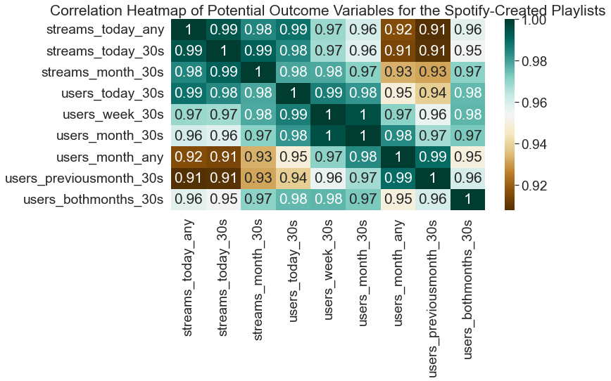

```python
spotify_outcome_data, spotify_heatmap = plot_outcome_corr(spotify_data)
spotify_heatmap.set_title('Correlation Heatmap of Potential Outcome Variables for the Spotify-Created Playlists');
```

## Principal Components Analysis of Potential Outcomes

We will continue our exploration of the relationship between the potential outcomes by performing a factor analysis. We observed that the correlation matrix for both the Spotify-created and user-created playlists is quite high. We would thus next like to address the question of to what degree can this information be reduced to one or a few factors, i.e. how much of the information encoded in these 9 potential outcomes is redundant. To help answer this question, we will employ a principal components analysis (PCA) on the user-created outcomes data. The results for the Spotify-created outcomes data are similar and can be found in the Appendix.

From the plot below, we see that the first principal component explains approximately 92% of the variation across the 9 potential outcomes, thus indicating that there is a great deal of redundancy in these measured outcomes. The second principal component explains another approximately 5% of variance. We can thus explain 97% of the variability of the 9 outcomes with 2 numbers (i.e. components).

```python
nonspotify_outcome_scaled = StandardScaler().fit_transform(nonspotify_outcome_data)
spotify_outcome_scaled = StandardScaler().fit_transform(spotify_outcome_data)
```

```python
def plot_percent_variation_explained(data, title):
    pca = PCA(n_components = data.shape[1])
    pca.fit(data)
    percent_explained = 100 * pca.explained_variance_ratio_.cumsum()
    percent_explained = np.insert(percent_explained, obj = 0, values = 0.0, axis = 0)
    plt.plot(percent_explained)
    plt.title(title,
             fontdict = {'fontsize': 16})
    plt.xlabel('Number of Principal Components',
             fontdict = {'fontsize': 16})
    plt.ylabel('Percent Variance Explained',
             fontdict = {'fontsize': 16});
```

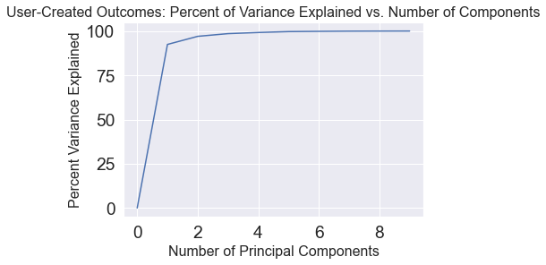

```python
 plot_percent_variation_explained(
     nonspotify_outcome_scaled,
     title = 'User-Created Outcomes: Percent of Variance Explained vs. Number of Components'
 )
```

Let's next consider the loadings of each of the first two principal components. In the plot below, we see that each of the 9 outcomes are weighted very equally for the first PC. This is to be expected given the high level of correlation amongst the predictors. Looking at the second PC, we see that the number of users in the previous month and the number of users in past two months have a sizeable negative weighting while the total streams today variables have noticeable positive weighting. This indicates that there are some differences in the behavior of the "total users over the course of months" variables and the "total streams today" variables. We, however, should be careful not to overemphasize these differences, given the high correlation between the variables and the fact that the first PC explainds 92% of variability across the outcomes. Nevertheless, when we proceed to modeling playlist success, we will consider two outcomes: total users who had a stream in both months and total users who streamed today.

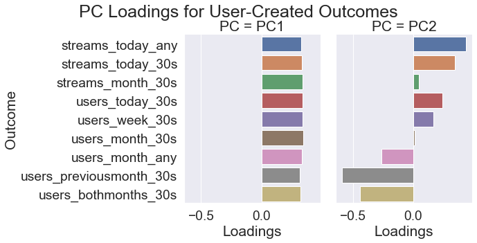

```python
def plot_pca_loadings(data_scaled, data, title, n_components = 2):
    pca = PCA(n_components = n_components)
    pca.fit(data_scaled)
    pca_loadings = pca.components_

    pca_df = (pd.DataFrame(pca_loadings.T,
                         columns = ['PC1', 'PC2'],
                         index = data.columns).
              reset_index().
              rename(columns = {'index': 'outcome'}).
              melt(id_vars = 'outcome',
                   value_vars = ['PC1', 'PC2'],
                   var_name = 'PC',
                       value_name = 'loading')
         )

    load_plot = sns.catplot(data = pca_df,
                kind = 'bar',
               y = 'outcome',
               x = 'loading',
               col = 'PC')

    load_plot.set_ylabels('Outcome')
    load_plot.set_xlabels('Loadings')
    load_plot.fig.suptitle(title, y = 1)

plot_pca_loadings(data_scaled = nonspotify_outcome_scaled,
                  data = nonspotify_outcome_data,
                 title = 'PC Loadings for User-Created Outcomes')
```

## Exploration of Predictors of Interest

```python
predictor_data = raw_data.loc[:, ['spotify_created'] + predictor_vars]
```

Note that for the plots below, we drew a random sample of user-created playlists for these plots in order for them not to visually swamp the Spotify-created playlists. Because the number of artists and albums in a playlist will tend to increase as the total tracks in a playlist increase, we define tracks per artist and tracks per album as scaled measures of the number of artists and albums that account for the overall size of the playlist. Also, note that the distribution of number of tracks, artists and albums does not vary between Spotify-created and user-created to the degree that the outcome variables do. However, we still observe some difference between user-created and Spotify-created playlists, namely that user-created playlists tend to have more tracks, artists and albums, with some user-created playlists having many more of each.

```python
np.random.seed(2)
continuous_predictors = (predictor_data.
                         loc[:, ['spotify_created',
                                 'n_tracks',
                                 #'n_local_tracks',
                                 'n_artists',
                                 'n_albums',]].
                         groupby('spotify_created').
                         # melt(var_name = 'predictor',
                         #     value_name = 'value').
                         sample(399)
                        )

# sns.pairplot(continuous_predictors,
#             hue = 'spotify_created')
```

```python
predictor_data['tracks_per_artist'] = predictor_data.n_tracks / predictor_data.n_artists
predictor_data['tracks_per_album'] = predictor_data.n_tracks / predictor_data.n_albums
```

Let's consider the correlation of the new scaled measures of artists and albums as well as whether we observe differences between the user-created and Spotify-created playlists. Notice that the distribution of tracks per artist and tracks per album appear quite similar for the user-created and Spotify-created playlists. Spotify-created playlist appear to exhibit a little bit more artist and album diversity than the user-created playlists, but the difference is miniscule compared to the outcome variables.

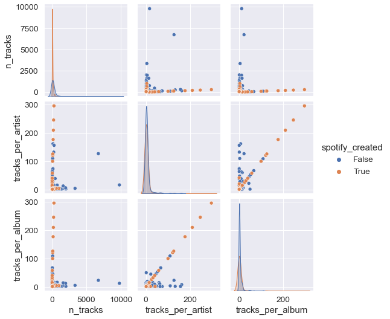

```python
np.random.seed(2)
scaled_predictors = (predictor_data.
                         loc[:, ['spotify_created',
                                 'n_tracks',
                                 #'n_local_tracks',
                                 'tracks_per_artist',
                                 'tracks_per_album',]].
                         groupby('spotify_created').
                         # melt(var_name = 'predictor',
                         #     value_name = 'value').
                         sample(399)
                        )

sns.set(font_scale = 1.25)
sns.pairplot(scaled_predictors,
            hue = 'spotify_created');
```

We now turn our attention to describing the categorical predictors: genre and mood.

```python
cat_vars = ['genre_1',
            'genre_2',
            'genre_3',
            'mood_1',
            'mood_2',
            'mood_3'
            ]

cat_preds = (predictor_data.
             loc[:, ['spotify_created'] + cat_vars]
            )
```

```python
def plot_cat_var(pred):

    cat_order = (cat_preds[pred].
                 value_counts().
                 reset_index().
                 rename(columns = {pred: 'count',
                                   'index': pred
                                  }).
                 sort_values('count', ascending = False)
                )

    my_plot = sns.barplot(
        data = cat_order,
        y = pred,
        x = 'count'
    )

    my_plot.set_title(f'Distribution of {pred}')

    return my_plot
```

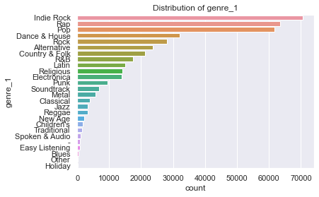

```python
sns.set(font_scale = 1)
plot_cat_var('genre_1');
```

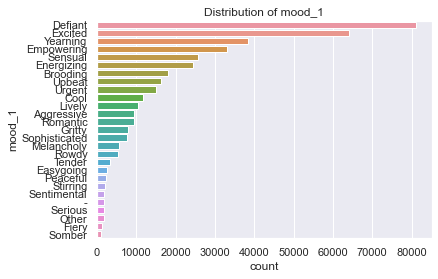

```python
plot_cat_var('mood_1');
```

# Predicting Playlist Success

We now turn our attention to predicting playlist success as measured by (1) the number of users who had a stream of greater than 30 seconds today (i.e. 'users_today_30s') and (2) the number of users who had a stream of greater than 30 seconds during the current month and the previous month (i.e. 'users_bothmonths_30s'). We choose 'users_today_30s' because amongst the user-created playlists, it very highly correlated with streams_today_any, streams_today_30s, streams_month_30s, users_week_30s, and users_month_30s (with the minimum correlation being 0.95). It is also less correlated with users_previousmonth_30s (0.83) and users_bothmonths_30s (0.88). We choose 'users_bothmonths_30s' because (1) it is less corelated than many of the other outcomes and (2) it is a good measure of a playlist's longer-term staying power. We build the models for both the Spotify-created and user-created playlist separately.

After fitting the models, we will then use SHAP values to help draw inference from the models. In particular, we will show plots of the most important predictors ranked by their mean absolute SHAP value. These plots will also highlight the directional effect of the predictor (i.e. the plots will showcase whether the given variable tends to be positively or negatively related to the outcome). We will also show plots for the categorical genre and mood variables that highlight which genres and moods tend to be related to higher and lower levels of playlist success.

Deriving measures of inferential uncertainty from gradient boosting models can be challenging. Thus, we also fit a robust M-estimation linear regression with a Huber loss function. These modeling results are presented in the Appendix. For the academically curious, we also present the results for an Ordinary Least Squares (OLS) model to show the importance of handling outliers in a robust fashion.

```python
def fit_lgb_mod(X, y):

    lgb_data = lgb.Dataset(data = X,
                          label = y,
                          params = {'verbose': -1}
                          )

    lgb_params = {'learning_rate': 1.0,
              'objective': 'huber' # deal with outliers
               }

    lgb_cv = lgb.cv(params = lgb_params,
                    train_set = lgb_data,
                    num_boost_round = 10000,
                    nfold = 10,
                    verbose_eval = -1,
                    stratified = False,
                    early_stopping_rounds = 25,
                    return_cvbooster = True)

    lgb_booster = lgb_cv.get('cvbooster')
    n_trees = lgb_booster.best_iteration

    lgb_mod = lgb.train(params = lgb_params,
                       train_set = lgb_data,
                       num_boost_round = n_trees,
                       verbose_eval = -1)

    return lgb_mod
```

```python
X = predictor_data.drop(columns = ['n_artists', 'n_albums'])
cat_columns = ['genre_1', 'genre_2', 'genre_3', 'mood_1', 'mood_2', 'mood_3']
for column in cat_columns:
    X[column] = X[column].astype('category')
```

```python
# Get the modeling input data for the Spotify-only models and no-Spotify models
X_spotify = X.query('spotify_created == True').drop(columns = 'spotify_created')
users_today_spotify = raw_data.query('spotify_created == True').loc[:, 'users_today_30s']
users_bothmonths_spotify = raw_data.query('spotify_created == True').loc[:, 'users_bothmonths_30s']


# Get the modeling input data for the Spotify-only models and no-Spotify models
X_nonspotify = X.query('spotify_created == False').drop(columns = 'spotify_created')
users_today_nonspotify = raw_data.query('spotify_created == False').loc[:, 'users_today_30s']
users_bothmonths_nonspotify = raw_data.query('spotify_created == False').loc[:, 'users_bothmonths_30s']
```

```python
%%capture
users_today_spotify_mod = fit_lgb_mod(X = X_spotify,
                                     y = users_today_spotify)
```

```python
%%capture
users_bothmonths_spotify_mod = fit_lgb_mod(X = X_spotify,
                                           y = users_bothmonths_spotify)
```

```python
def create_model_explanations(mod,
                              X,
                              #n_samples = 2000000,
                              vars_plot_dependence = ['genre_1', 'mood_1']):

    #n_samples = min(n_samples, len(X))
    explainer = shap.TreeExplainer(mod)
    X_reduced = X#.sample(n_samples)
    shap_values = explainer.shap_values(X_reduced)

    # shap_summary = shap.summary_plot(
    #     np.delete(shap_values, obj = 0, axis = 1),
    #     X_reduced.drop(columns = 'spotify_created'))

    shap_summary = shap.summary_plot(shap_values, X_reduced)

    plt.show(shap_summary)

    #top_inds = np.argsort(-np.sum(np.abs(shap_values), 0))

    for var in vars_plot_dependence:
        shap.dependence_plot(var,
                             shap_values,
                             X_reduced,
                            interaction_index = None)
```

## Spotify-Created Playlists: Modeling Results for Number of Users Today

From the first plot below, we see that amongst the Spotify-created playlists, the most important variable predicting success is the number of tracks, followed by the primary mood, tracks per album and tracks per artist. Also, notice that large values of tracks (colored in pink) tend to be associated with larger SHAP values. Thus, we find that playlists with more tracks tend to have more users today. On the other hand, notice that for tracks per album and tracks per artist, the large values tend to be associated with negative SHAP values. Thus, large tracks per artist and tracks per album tend to be associated with reduced playlist success. Said another way, increasing the musical diversity of a playlist tends to increase playlist success as measured by number of users today.

The first plot does not easily allow us to understand individal levels of the categorical predictors of mood and genre. We thus plot SHAP values for each level of the primary genre and primary mood below. From the plot for primary genre, we can see that 'Dance and House' and 'Pop' music tends to be positively related to playlist success, while 'Country and Folk', 'Electronica' and 'Rock' tend to negatively related to success (again, as measured by number of users today).

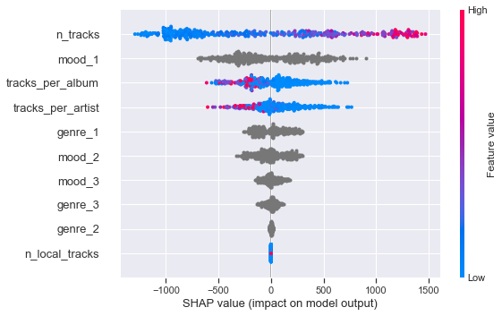

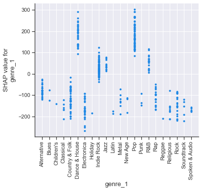

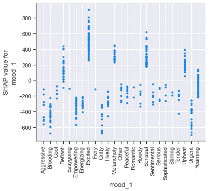

```python
create_model_explanations(mod = users_today_spotify_mod,
                          X = X_spotify)
```

```python
%%capture
users_today_nonspotify_mod = fit_lgb_mod(X = X_nonspotify,
                                     y = users_today_nonspotify)
```

```python
%%capture
users_bothmonths_nonspotify_mod = fit_lgb_mod(X = X_nonspotify,
                                     y = users_bothmonths_nonspotify)
```

## User-Created Playlists: Modeling Results for Number of Users Today

For the user-created playlists, we see that increasing the number of tracks is also associated with increased number of users today. Genre appears relatively more important than in the Spotify playlists. The most successful genres for the user-created playlists are "Children's", "Latin" and "Traditional". In a robust linear regression model, each of these genres are found to be significantly more successful than genre = "-".

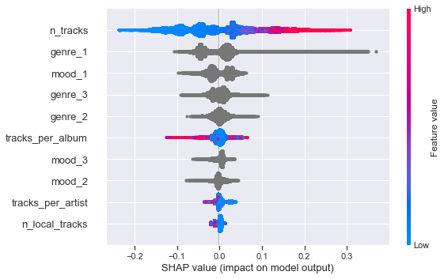

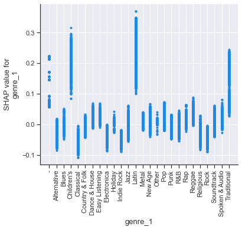

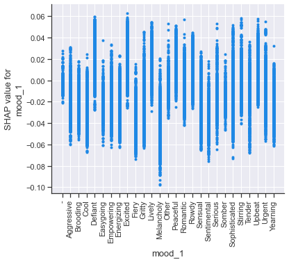

```python
create_model_explanations(mod = users_today_nonspotify_mod,
                          X = X_nonspotify)
```

```python
#shap.initjs()
# shap.force_plot(base_value = explainer.expected_value,
#                shap_values = shap_values,
#                features = X_reduced)
```

```python
#shap.force_plot(explainer.expected_value, shap_values[0, :], X.iloc[0, :])
```

# Appendix

## Spotify-Created Playlists: Modeling Results for Number of Users in Current and Previous Month

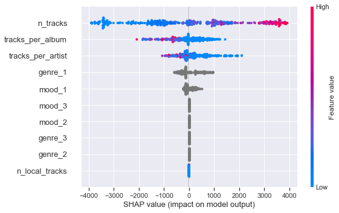

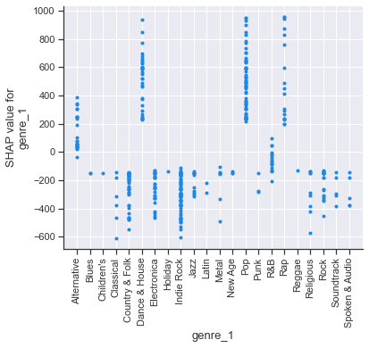

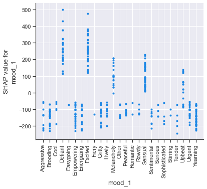

```python
create_model_explanations(mod = users_bothmonths_spotify_mod,
                          X = X_spotify)
```

## User-Created Playlists: Modeling Results for Number of Users in Current and Previous Month

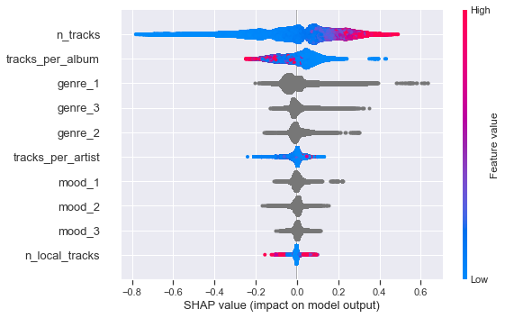

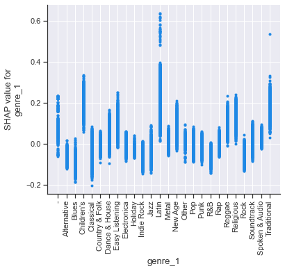

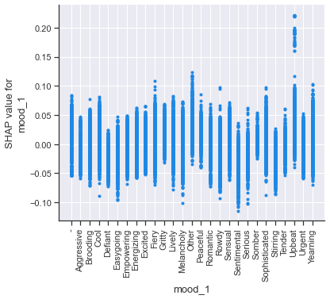

```python
create_model_explanations(mod = users_bothmonths_nonspotify_mod,
                          X = X_nonspotify)
```

## Assumptions:

1. This is a random sample of playlists. If this a biased sample, then any generalizations that we make from the data is likely to be meaningfully inaccurate.
2. Spotify treats each user-created playlist equally in terms of promotion. For examples, if the Spotify algorithms were promoting some genres above others at the time this data was collected, then we are unlikely to get a good read on how genre affects listenership.
3. (a) Spotify treats its own playlists differently than the non-Spotify playlists. If this assumption is correct, then it is likely that Spotify playlists are not particularly comparable to non-Spotify playlists.  
   (b) Spotify treats its own playlists equally with each other. Thus, an analysis with only Spotify playlists should be okay.
4. Each playlist included in the dataset has existed for at least two months. This ensures that the monthly average users in the previous month variable is not biased by how long the playlist has existed.
5. The Spotify algorithms do not amplify small variations in success. If playlist A was slightly more successful than Playlist B two months ago under 'fair' algorithmic treatment, then the algorithms will not amplify playlist A over playlist B, and thus widen the gulf between the success of the two playlists. In other words, there is a fair marketplace for the playlists to compete, where success does not necessarily beget success simply due to the algorithms.
6. For the categorical variables, genre_1-genre_3 and mood_1-mood_3, when the value is '-' this is not a missing value, but is instead imparting the information that the given playlist does not easily fit into the predefined genre and mood types.

## PCA Analysis of Outcomes for Spotify-Created Playlists

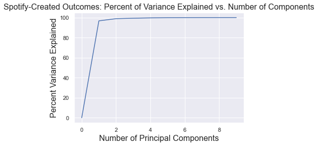

```python
 plot_percent_variation_explained(
     spotify_outcome_scaled,
     title = 'Spotify-Created Outcomes: Percent of Variance Explained vs. Number of Components'
 )
```

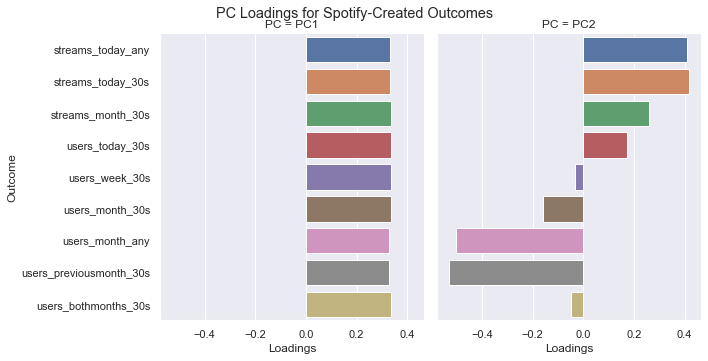

```python
plot_pca_loadings(data_scaled = spotify_outcome_scaled,
                  data = spotify_outcome_data,
                 title = 'PC Loadings for Spotify-Created Outcomes')
```

## Plots of Distribution of Secondary and Tertiary Genre and Mood

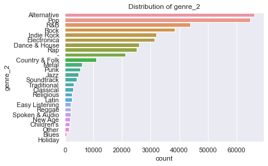

```python
plot_cat_var('genre_2');
```

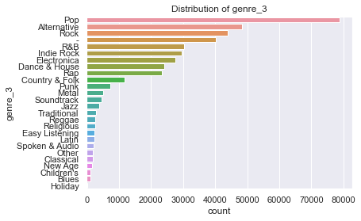

```python
plot_cat_var('genre_3');
```

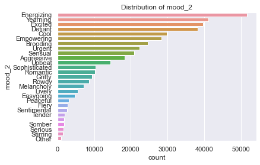

```python
plot_cat_var('mood_2');
```

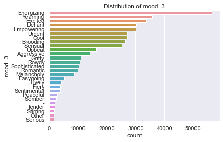

```python
plot_cat_var('mood_3');
```

## Robust Linear Regression Model Results

### RLM Model for Spotify-Created Playlists, Outcome = Users Today

```python
user_data = pd.concat([users_today_nonspotify, users_bothmonths_nonspotify, X_nonspotify], axis = 1)
spotify_data = pd.concat([users_today_spotify, users_bothmonths_spotify, X_spotify], axis = 1)
```

```python
def fit_huber_model(data, outcome):

    y, X = dmatrices(f'{outcome} ~ n_tracks + tracks_per_album + genre_1 + mood_1',
                data = data,
                return_type = 'dataframe')

    huber_t = sm.RLM(y, X, M = sm.robust.norms.HuberT()).fit()

    print(huber_t.summary2())

    return huber_t
```

```python
fit_huber_model(data = spotify_data,
                outcome = 'users_today_30s')
```

```
                           Results: Robust linear model
==================================================================================
Model:                       RLM                      Df Residuals:         351
Dependent Variable:          users_today_30s          Norm:                 HuberT
Date:                        2022-02-23 19:28         Scale Est.:           mad
No. Observations:            399                      Cov. Type:            H1
Df Model:                    47                       Scale:                1289.6
----------------------------------------------------------------------------------
                            Coef.     Std.Err.    z    P>|z|    [0.025     0.975]
----------------------------------------------------------------------------------
Intercept                   592.5850  210.9870  2.8086 0.0050   179.0581 1006.1119
genre_1[T.Alternative]      321.4248  387.0639  0.8304 0.4063  -437.2066 1080.0561
genre_1[T.Blues]           1730.9971 1164.6920  1.4862 0.1372  -551.7574 4013.7515
genre_1[T.Children's]      -445.0210 1603.4611 -0.2775 0.7814 -3587.7470 2697.7050
genre_1[T.Classical]       1301.9412 1010.0657  1.2890 0.1974  -677.7513 3281.6336
genre_1[T.Country & Folk]  -169.5201  365.2716 -0.4641 0.6426  -885.4392  546.3991
genre_1[T.Dance & House]    660.8945  377.2358  1.7519 0.0798   -78.4740 1400.2630
genre_1[T.Easy Listening]    -0.0000    0.0000 -0.5453 0.5855    -0.0000    0.0000
genre_1[T.Electronica]     -603.0586  405.2874 -1.4880 0.1368 -1397.4072  191.2900
genre_1[T.Holiday]         -199.2876 1612.9078 -0.1236 0.9017 -3360.5288 2961.9536
genre_1[T.Indie Rock]       266.7984  283.7900  0.9401 0.3472  -289.4198  823.0166
genre_1[T.Jazz]            -360.3224  556.3045 -0.6477 0.5172 -1450.6592  730.0144
genre_1[T.Latin]             -5.5204 1156.6357 -0.0048 0.9962 -2272.4847 2261.4439
genre_1[T.Metal]           -147.9796  714.6698 -0.2071 0.8360 -1548.7068 1252.7475
genre_1[T.New Age]         -570.1787 1000.4309 -0.5699 0.5687 -2530.9872 1390.6299
genre_1[T.Other]              0.0000    0.0000  1.7542 0.0794    -0.0000    0.0000
genre_1[T.Pop]              695.8092  296.2827  2.3485 0.0189   115.1058 1276.5127
genre_1[T.Punk]              17.1923  961.5249  0.0179 0.9857 -1867.3619 1901.7465
genre_1[T.R&B]              365.5038  452.5511  0.8077 0.4193  -521.4800 1252.4876
genre_1[T.Rap]              296.8161  501.3839  0.5920 0.5539  -685.8783 1279.5104
genre_1[T.Reggae]           198.2037 1805.6950  0.1098 0.9126 -3340.8934 3737.3008
genre_1[T.Religious]       -931.6740  613.0447 -1.5197 0.1286 -2133.2195  269.8714
genre_1[T.Rock]            -516.6896  418.6339 -1.2342 0.2171 -1337.1970  303.8178
genre_1[T.Soundtrack]     -1068.7898  966.9534 -1.1053 0.2690 -2963.9836  826.4040
genre_1[T.Spoken & Audio]  -244.9543 1205.7641 -0.2032 0.8390 -2608.2086 2118.3000
genre_1[T.Traditional]       -0.0000    0.0000 -0.3063 0.7594    -0.0000    0.0000
mood_1[T.Aggressive]       -254.2457  631.9588 -0.4023 0.6875 -1492.8622  984.3709
mood_1[T.Brooding]         -437.9987  363.1691 -1.2060 0.2278 -1149.7970  273.7997
mood_1[T.Cool]             -221.0991  893.3308 -0.2475 0.8045 -1971.9953 1529.7971
mood_1[T.Defiant]           140.3623  381.5733  0.3679 0.7130  -607.5076  888.2322
```

[output cut: 10 more lines]

```
mood_1[T.Romantic]          167.0885 1472.1465  0.1135 0.9096 -2718.2655 3052.4426
mood_1[T.Rowdy]            -126.0988  682.2825 -0.1848 0.8534 -1463.3478 1211.1502
mood_1[T.Sensual]           372.3687  345.6100  1.0774 0.2813  -305.0144 1049.7519
mood_1[T.Sentimental]       951.1252  614.1904  1.5486 0.1215  -252.6658 2154.9162
mood_1[T.Serious]          -504.0052  932.1720 -0.5407 0.5887 -2331.0287 1323.0182
mood_1[T.Somber]             -0.0000    0.0000 -0.8718 0.3833    -0.0000    0.0000
mood_1[T.Sophisticated]    3097.9696  835.1919  3.7093 0.0002  1461.0235 4734.9158
mood_1[T.Stirring]         -778.8670 1276.0579 -0.6104 0.5416 -3279.8946 1722.1606
mood_1[T.Tender]            989.2884  948.0818  1.0435 0.2967  -868.9177 2847.4945
mood_1[T.Upbeat]            752.1248  445.0139  1.6901 0.0910  -120.0865 1624.3361
mood_1[T.Urgent]           -625.8362  399.0035 -1.5685 0.1168 -1407.8687  156.1962
mood_1[T.Yearning]         -163.0275  328.3333 -0.4965 0.6195  -806.5490  480.4940
n_tracks                      4.3197    1.0171  4.2470 0.0000     2.3261    6.3132
tracks_per_album             23.7652    3.3748  7.0419 0.0000    17.1507   30.3798
==================================================================================
```

```
<statsmodels.robust.robust_linear_model.RLMResultsWrapper at 0x2330c95f070>
```

### RLM Model of User-Created Playlists, Outcome = Users Today

Note that for the following model outputs, the baseline level for both the genre and mood categorical predictors is "-", which I am taking to mean there is no easily discernible genre or mood detectable for the given playlist.

```python
fit_huber_model(data = user_data,
                outcome = 'users_today_30s')
```

```
                      Results: Robust linear model
=========================================================================
Model:                   RLM                   Df Residuals:      402913
Dependent Variable:      users_today_30s       Norm:              HuberT
Date:                    2022-02-23 19:29      Scale Est.:        mad
No. Observations:        402967                Cov. Type:         H1
Df Model:                53                    Scale:             0.73545
-------------------------------------------------------------------------
                           Coef.  Std.Err.    z    P>|z|   [0.025  0.975]
-------------------------------------------------------------------------
Intercept                  0.4775   0.0191 25.0304 0.0000  0.4401  0.5149
genre_1[T.Alternative]    -0.0373   0.0280 -1.3342 0.1821 -0.0922  0.0175
genre_1[T.Blues]          -0.0499   0.0392 -1.2741 0.2026 -0.1268  0.0269
genre_1[T.Children's]      0.1435   0.0312  4.6023 0.0000  0.0824  0.2046
genre_1[T.Classical]      -0.0907   0.0293 -3.0895 0.0020 -0.1482 -0.0331
genre_1[T.Country & Folk]  0.0057   0.0281  0.2024 0.8396 -0.0495  0.0609
genre_1[T.Dance & House]   0.0254   0.0280  0.9064 0.3648 -0.0295  0.0802
genre_1[T.Easy Listening]  0.0205   0.0338  0.6068 0.5440 -0.0457  0.0867
genre_1[T.Electronica]    -0.0404   0.0282 -1.4323 0.1520 -0.0956  0.0149
genre_1[T.Holiday]         0.0271   0.0542  0.5004 0.6168 -0.0792  0.1335
genre_1[T.Indie Rock]     -0.0407   0.0279 -1.4625 0.1436 -0.0953  0.0139
genre_1[T.Jazz]           -0.0234   0.0296 -0.7878 0.4308 -0.0815  0.0347
genre_1[T.Latin]           0.2287   0.0282  8.1150 0.0000  0.1734  0.2839
genre_1[T.Metal]           0.0101   0.0289  0.3495 0.7267 -0.0465  0.0667
genre_1[T.New Age]        -0.0051   0.0302 -0.1702 0.8649 -0.0643  0.0540
genre_1[T.Other]          -0.0759   0.0519 -1.4627 0.1436 -0.1775  0.0258
genre_1[T.Pop]             0.0018   0.0278  0.0654 0.9478 -0.0527  0.0564
genre_1[T.Punk]           -0.0318   0.0284 -1.1182 0.2635 -0.0875  0.0239
genre_1[T.R&B]            -0.0094   0.0281 -0.3351 0.7375 -0.0646  0.0457
genre_1[T.Rap]             0.0399   0.0279  1.4292 0.1529 -0.0148  0.0946
genre_1[T.Reggae]          0.0639   0.0297  2.1478 0.0317  0.0056  0.1221
genre_1[T.Religious]      -0.0631   0.0282 -2.2376 0.0253 -0.1183 -0.0078
genre_1[T.Rock]           -0.0452   0.0280 -1.6176 0.1058 -0.1000  0.0096
genre_1[T.Soundtrack]     -0.0039   0.0286 -0.1350 0.8926 -0.0599  0.0522
genre_1[T.Spoken & Audio] -0.0047   0.0332 -0.1404 0.8883 -0.0698  0.0605
genre_1[T.Traditional]     0.0993   0.0314  3.1655 0.0015  0.0378  0.1609
mood_1[T.Aggressive]      -0.0045   0.0212 -0.2115 0.8325 -0.0460  0.0370
mood_1[T.Brooding]        -0.0226   0.0207 -1.0891 0.2761 -0.0632  0.0180
mood_1[T.Cool]            -0.0174   0.0210 -0.8280 0.4077 -0.0586  0.0238
mood_1[T.Defiant]          0.0532   0.0204  2.6097 0.0091  0.0133  0.0932
```

[output cut: 10 more lines]

```
mood_1[T.Romantic]        -0.0045   0.0211 -0.2133 0.8311 -0.0458  0.0368
mood_1[T.Rowdy]            0.0042   0.0218  0.1908 0.8487 -0.0386  0.0469
mood_1[T.Sensual]         -0.0135   0.0206 -0.6539 0.5132 -0.0538  0.0269
mood_1[T.Sentimental]     -0.0833   0.0246 -3.3923 0.0007 -0.1315 -0.0352
mood_1[T.Serious]         -0.0143   0.0250 -0.5703 0.5685 -0.0633  0.0348
mood_1[T.Somber]          -0.0623   0.0280 -2.2258 0.0260 -0.1171 -0.0074
mood_1[T.Sophisticated]    0.0033   0.0213  0.1543 0.8774 -0.0384  0.0450
mood_1[T.Stirring]         0.0200   0.0244  0.8224 0.4109 -0.0277  0.0678
mood_1[T.Tender]           0.0062   0.0229  0.2732 0.7847 -0.0386  0.0510
mood_1[T.Upbeat]           0.0372   0.0209  1.7755 0.0758 -0.0039  0.0783
mood_1[T.Urgent]           0.0178   0.0208  0.8549 0.3926 -0.0230  0.0586
mood_1[T.Yearning]        -0.0143   0.0205 -0.6987 0.4847 -0.0544  0.0258
n_tracks                   0.0001   0.0000 53.0255 0.0000  0.0001  0.0001
tracks_per_album          -0.0000   0.0000 -1.6380 0.1014 -0.0000  0.0000
=========================================================================
```

```
<statsmodels.robust.robust_linear_model.RLMResultsWrapper at 0x2330b8c00d0>
```

### OLS Model of User Created Playlists, Outcome = Users Today

This is a model of number of users today for the non-Spotify playlists. Take note of the incredibly large standard errors on our estimates when we do not employ a loss function that is robust to outliers.

```python
ols_user = smf.ols('users_today_30s ~ n_tracks + tracks_per_artist + genre_1 + mood_1',
               data = user_data).fit()

print(ols_user.summary2())
```

```
                    Results: Ordinary least squares
========================================================================
Model:               OLS               Adj. R-squared:      0.000
Dependent Variable:  users_today_30s   AIC:                 4140974.1152
Date:                2022-02-23 19:29  BIC:                 4141563.0721
No. Observations:    402967            Log-Likelihood:      -2.0704e+06
Df Model:            53                F-statistic:         1.180
Df Residuals:        402913            Prob (F-statistic):  0.173
R-squared:           0.000             Scale:               1699.7
------------------------------------------------------------------------
                           Coef.  Std.Err.    t    P>|t|   [0.025 0.975]
------------------------------------------------------------------------
Intercept                  1.2035   1.3420  0.8968 0.3698 -1.4268 3.8338
genre_1[T.Alternative]    -0.5632   1.9695 -0.2860 0.7749 -4.4233 3.2969
genre_1[T.Blues]          -0.4999   2.7576 -0.1813 0.8562 -5.9047 4.9049
genre_1[T.Children's]      1.1479   2.1936  0.5233 0.6008 -3.1515 5.4473
genre_1[T.Classical]      -1.1414   2.0647 -0.5528 0.5804 -5.1882 2.9054
genre_1[T.Country & Folk] -0.6222   1.9803 -0.3142 0.7534 -4.5036 3.2591
genre_1[T.Dance & House]  -0.0923   1.9686 -0.0469 0.9626 -3.9507 3.7661
genre_1[T.Easy Listening] -0.6473   2.3767 -0.2724 0.7854 -5.3056 4.0110
genre_1[T.Electronica]    -0.8544   1.9821 -0.4310 0.6664 -4.7392 3.0305
genre_1[T.Holiday]        -0.5885   3.8160 -0.1542 0.8774 -8.0678 6.8909
genre_1[T.Indie Rock]     -0.7986   1.9597 -0.4075 0.6836 -4.6396 3.0424
genre_1[T.Jazz]           -0.4959   2.0855 -0.2378 0.8120 -4.5834 3.5916
genre_1[T.Latin]           0.5322   1.9823  0.2685 0.7883 -3.3531 4.4176
genre_1[T.Metal]          -0.5730   2.0306 -0.2822 0.7778 -4.5529 3.4069
genre_1[T.New Age]        -0.9145   2.1236 -0.4306 0.6667 -5.0767 3.2477
genre_1[T.Other]          -0.8709   3.6496 -0.2386 0.8114 -8.0240 6.2821
genre_1[T.Pop]            -0.2399   1.9576 -0.1225 0.9025 -4.0766 3.5969
genre_1[T.Punk]           -0.8336   2.0002 -0.4168 0.6769 -4.7540 3.0868
genre_1[T.R&B]            -0.7183   1.9798 -0.3628 0.7167 -4.5986 3.1620
genre_1[T.Rap]            -0.3503   1.9636 -0.1784 0.8584 -4.1988 3.4983
genre_1[T.Reggae]         -0.3277   2.0920 -0.1566 0.8755 -4.4279 3.7725
genre_1[T.Religious]      -0.7106   1.9828 -0.3584 0.7201 -4.5968 3.1756
genre_1[T.Rock]           -0.0104   1.9670 -0.0053 0.9958 -3.8656 3.8448
genre_1[T.Soundtrack]      0.3482   2.0116  0.1731 0.8626 -3.5945 4.2910
genre_1[T.Spoken & Audio] -0.5224   2.3385 -0.2234 0.8232 -5.1059 4.0610
genre_1[T.Traditional]     0.6116   2.2080  0.2770 0.7818 -3.7159 4.9392
mood_1[T.Aggressive]       0.5344   1.4906  0.3585 0.7199 -2.3870 3.4559
mood_1[T.Brooding]         0.0589   1.4573  0.0404 0.9677 -2.7973 2.9151
```

[output cut: 19 more lines]

```
mood_1[T.Stirring]         0.1790   1.7150  0.1044 0.9169 -3.1823 3.5403
mood_1[T.Tender]           0.3622   1.6079  0.2252 0.8218 -2.7892 3.5136
mood_1[T.Upbeat]           0.7530   1.4738  0.5109 0.6094 -2.1356 3.6417
mood_1[T.Urgent]           0.2116   1.4655  0.1444 0.8852 -2.6608 3.0839
mood_1[T.Yearning]         0.1184   1.4399  0.0822 0.9345 -2.7037 2.9404
n_tracks                   0.0003   0.0001  2.5696 0.0102  0.0001 0.0005
tracks_per_artist         -0.0005   0.0007 -0.7858 0.4320 -0.0018 0.0008
------------------------------------------------------------------------
Omnibus:           2142164.888   Durbin-Watson:      1.999
Prob(Omnibus):     0.000         Jarque-Bera (JB):   180443014585193.719
Skew:              268.776       Prob(JB):           0.000
Kurtosis:          103668.698    Condition No.:      108308
========================================================================
* The condition number is large (1e+05). This might indicate
strong multicollinearity or other numerical problems.
```